# SeqMonk Vistory Report

## Project Summary

### Basic Project Info

| Parameter | Value |
| --- | --- |
| Project Name | pluripotency_exit_hmC.smk |
| Vistory Name | pluripotency_exit_hmC_210513.smv |
| Genome | Mus musculus GRCm38_v100 |
| SeqMonk Version | 1.48.0 |

### Data Sets

| Name | File Name | Reads | Import Options |
| --- | --- | --- | --- |
| lane7624_AAGTCCA_TET_WT_1_1_L001_GRCm38_bowtie2.bam | C:\Users\kruegerc\Downloads\lane7624_AAGTCCA_TET_WT_1_1_L001_GRCm38_bowtie2.bam | 5066125 | Library type Single End Dedup=No MAPQ>=20 Primary alignments only. Extend reads by 225 |
| lane7624_AATGCCT_DNMT_WT_2_2_L001_GRCm38_bowtie2.bam | C:\Users\kruegerc\Downloads\lane7624_AATGCCT_DNMT_WT_2_2_L001_GRCm38_bowtie2.bam | 14178685 | Library type Single End Dedup=No MAPQ>=20 Primary alignments only. Extend reads by 225 |
| lane7624_AGTTCAG_TET_WT_2_3_L001_GRCm38_bowtie2.bam | C:\Users\kruegerc\Downloads\lane7624_AGTTCAG_TET_WT_2_3_L001_GRCm38_bowtie2.bam | 23573019 | Library type Single End Dedup=No MAPQ>=20 Primary alignments only. Extend reads by 225 |
| lane7624_ATCCACT_TET_WT_1_2_L001_GRCm38_bowtie2.bam | C:\Users\kruegerc\Downloads\lane7624_ATCCACT_TET_WT_1_2_L001_GRCm38_bowtie2.bam | 6321146 | Library type Single End Dedup=No MAPQ>=20 Primary alignments only. Extend reads by 225 |
| lane7624_CAAGCTA_TET_WT_2_1_L001_GRCm38_bowtie2.bam | C:\Users\kruegerc\Downloads\lane7624_CAAGCTA_TET_WT_2_1_L001_GRCm38_bowtie2.bam | 24178991 | Library type Single End Dedup=No MAPQ>=20 Primary alignments only. Extend reads by 225 |
| lane7624_CCGCGGT_TET_WT_0_1_L001_GRCm38_bowtie2.bam | C:\Users\kruegerc\Downloads\lane7624_CCGCGGT_TET_WT_0_1_L001_GRCm38_bowtie2.bam | 44463991 | Library type Single End Dedup=No MAPQ>=20 Primary alignments only. Extend reads by 225 |
| lane7624_GCTTGTC_TET_WT_1_3_L001_GRCm38_bowtie2.bam | C:\Users\kruegerc\Downloads\lane7624_GCTTGTC_TET_WT_1_3_L001_GRCm38_bowtie2.bam | 23661978 | Library type Single End Dedup=No MAPQ>=20 Primary alignments only. Extend reads by 225 |
| lane7624_GGACTTG_TET_WT_0_3_L001_GRCm38_bowtie2.bam | C:\Users\kruegerc\Downloads\lane7624_GGACTTG_TET_WT_0_3_L001_GRCm38_bowtie2.bam | 42584273 | Library type Single End Dedup=No MAPQ>=20 Primary alignments only. Extend reads by 225 |
| lane7624_GGCATTC_DNMT_WT_2_1_L001_GRCm38_bowtie2.bam | C:\Users\kruegerc\Downloads\lane7624_GGCATTC_DNMT_WT_2_1_L001_GRCm38_bowtie2.bam | 35637001 | Library type Single End Dedup=No MAPQ>=20 Primary alignments only. Extend reads by 225 |
| lane7624_TACCGAG_DNMT_WT_2_3_L001_GRCm38_bowtie2.bam | C:\Users\kruegerc\Downloads\lane7624_TACCGAG_DNMT_WT_2_3_L001_GRCm38_bowtie2.bam | 25518826 | Library type Single End Dedup=No MAPQ>=20 Primary alignments only. Extend reads by 225 |
| lane7624_TGGATCG_TET_WT_2_2_L001_GRCm38_bowtie2.bam | C:\Users\kruegerc\Downloads\lane7624_TGGATCG_TET_WT_2_2_L001_GRCm38_bowtie2.bam | 17411480 | Library type Single End Dedup=No MAPQ>=20 Primary alignments only. Extend reads by 225 |
| lane7624_TTATAAC_TET_WT_0_2_L001_GRCm38_bowtie2.bam | C:\Users\kruegerc\Downloads\lane7624_TTATAAC_TET_WT_0_2_L001_GRCm38_bowtie2.bam | 25705722 | Library type Single End Dedup=No MAPQ>=20 Primary alignments only. Extend reads by 225 |

Data Set Renamed

lane7624_AATGCCT_DNMT_WT_2_2_L001_GRCm38_bowtie2.bam changed to lane7624_AATGCCT_DNMT_WT_2_2

Data Set Renamed

lane7624_AGTTCAG_TET_WT_2_3_L001_GRCm38_bowtie2.bam changed to lane7624_AGTTCAG_TET_WT_2_3

Data Set Renamed

lane7624_ATCCACT_TET_WT_1_2_L001_GRCm38_bowtie2.bam changed to lane7624_ATCCACT_TET_WT_1_2

Data Set Renamed

lane7624_CAAGCTA_TET_WT_2_1_L001_GRCm38_bowtie2.bam changed to lane7624_CAAGCTA_TET_WT_2_1

Data Set Renamed

lane7624_CCGCGGT_TET_WT_0_1_L001_GRCm38_bowtie2.bam changed to lane7624_CCGCGGT_TET_WT_0_1

Data Set Renamed

lane7624_GCTTGTC_TET_WT_1_3_L001_GRCm38_bowtie2.bam changed to lane7624_GCTTGTC_TET_WT_1_3

Data Set Renamed

lane7624_GGACTTG_TET_WT_0_3_L001_GRCm38_bowtie2.bam changed to lane7624_GGACTTG_TET_WT_0_3

Data Set Renamed

lane7624_GGCATTC_DNMT_WT_2_1_L001_GRCm38_bowtie2.bam changed to lane7624_GGCATTC_DNMT_WT_2_1

Data Set Renamed

lane7624_TACCGAG_DNMT_WT_2_3_L001_GRCm38_bowtie2.bam changed to lane7624_TACCGAG_DNMT_WT_2_3

Data Set Renamed

lane7624_TGGATCG_TET_WT_2_2_L001_GRCm38_bowtie2.bam changed to lane7624_TGGATCG_TET_WT_2_2

Data Set Renamed

lane7624_TTATAAC_TET_WT_0_2_L001_GRCm38_bowtie2.bam changed to lane7624_TTATAAC_TET_WT_0_2

Data Set Renamed

lane7624_AAGTCCA_TET_WT_1_1 changed to TET_WT_1_1

Data Set Renamed

lane7624_AATGCCT_DNMT_WT_2_2 changed to DNMT_WT_2_2

Data Set Renamed

lane7624_AGTTCAG_TET_WT_2_3 changed to TET_WT_2_3

Data Set Renamed

lane7624_ATCCACT_TET_WT_1_2 changed to TET_WT_1_2

Data Set Renamed

lane7624_CAAGCTA_TET_WT_2_1 changed to TET_WT_2_1

Data Set Renamed

lane7624_CCGCGGT_TET_WT_0_1 changed to TET_WT_0_1

Data Set Renamed

lane7624_GCTTGTC_TET_WT_1_3 changed to TET_WT_1_3

Data Set Renamed

lane7624_GGACTTG_TET_WT_0_3 changed to TET_WT_0_3

Data Set Renamed

lane7624_GGCATTC_DNMT_WT_2_1 changed to DNMT_WT_2_1

Data Set Renamed

lane7624_TACCGAG_DNMT_WT_2_3 changed to DNMT_WT_2_3

Data Set Renamed

lane7624_TGGATCG_TET_WT_2_2 changed to TET_WT_2_2

Data Set Renamed

lane7624_TTATAAC_TET_WT_0_2 changed to TET_WT_0_2

New Probe Set:2 kb tiles (1362779 probes)

Running windows of size 2000 with step size 2000

Probes Quantitated

Read Count Quantitation using All Reads correcting for total count per million reads log transformed

### cumulative distributions

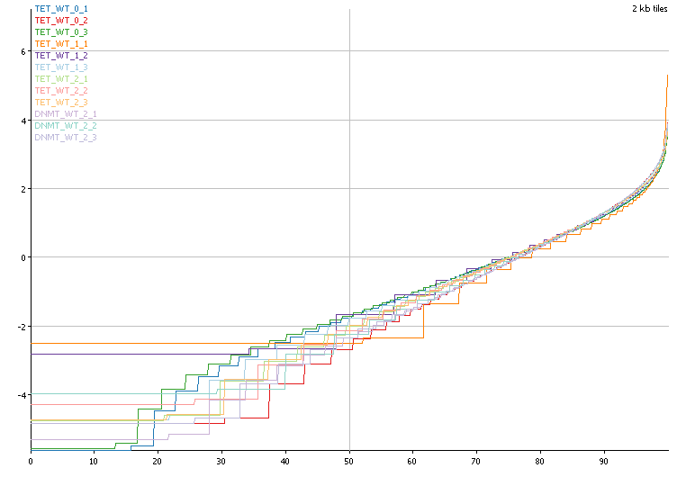

### data store similaritly

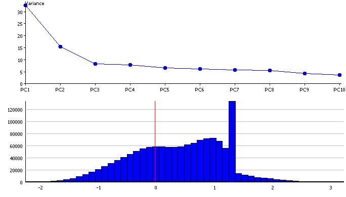

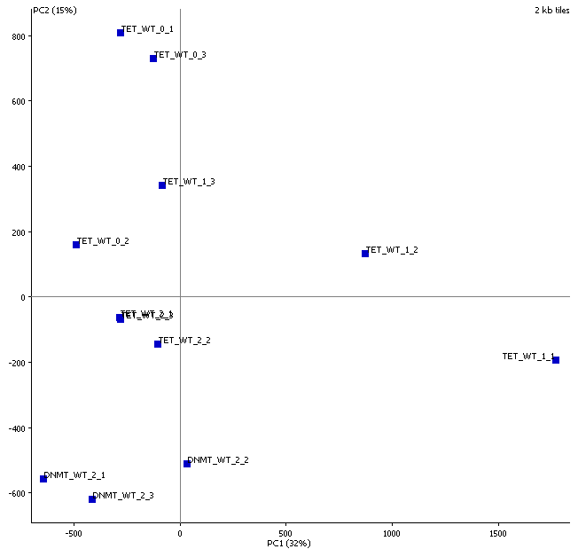

Looks like PC1 is sparseness of data, and PC2 is level of hydroxy.

Random example regions to show sparseness (apart from the data store report)

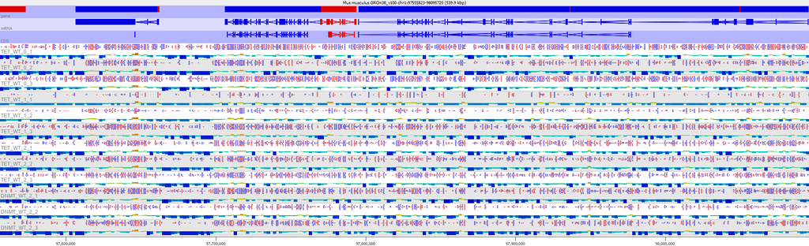

### Duplication

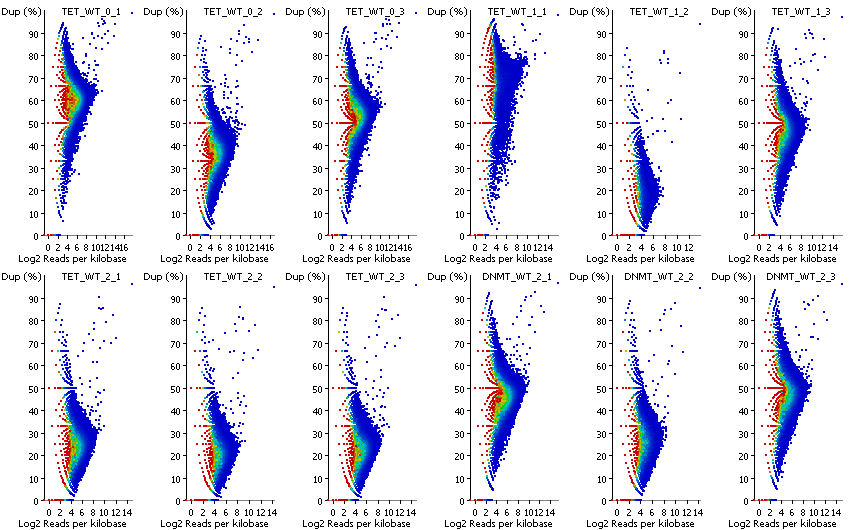

some samples have considerable amounts of duplication

Annotation Sets Added

Added 4 annotation sets paradigm_ES_enhancer_tiles_210507.txt - 19377 features paradigm_Epi_enhancer_tiles_210507.txt - 4157 features paradigm_constitutive_bivalent_enhancer_tiles_210507.txt - 772 features paradigm_constitutive_enhancer_tiles_210507.txt - 19049 features

New Probe Set:paradigm enhancers (43355 probes)

Feature generator using paradigm_constitutive_bivalent_enhancer paradigm_constitutive_enhancer paradigm_Epi_enhancer paradigm_ES_enhancer duplicates removed Over feature from 0-0

Probes Quantitated

Read Count Quantitation using All Reads correcting for total count per million reads log transformed

Annotation Sets Added

Added 1 annotation set paradigm enhancers - 43355 features

Exported annotated probe report